# RangeMap Annual Fuel Model Assignments Analysis

Analyzing annual fuel model assignments from RangeMap and LANDFIRE, compared with annual climate anomalies

August 21, 2026

## Overview

This document shows how FBFM40 fuel model assignments derived from **RangeMap** vary in response to annual climate anomalies (spring/winter precipitation and vapor pressure deficit) from 2022, 2024, and 2025. This example shows an AOI in Southwest Arizona.

As a benchmark, the same fuel model comparison is repeated using the respective **LANDFIRE** FBFM40 fuel model products, which are expected to show little to no year-to-year change.

## Area of Interest

This example shows an area of Southwest Arizona where there were recent large precipitation anomalies.

[interactive chart not shown]

## Annual Climate Anomalies

Winter and spring precipitation and vapor pressure deficit anomalies were cropped to the AOI and averaged to produce a single mean anomaly value per year/season/variable in the AOI. 2022 was the most typical year I could find recently (little anomaly in winter precipitation; spring precipitation twice normal; but with high vapor pressure deficit); 2024 was extremely wet (14 to 20 times normal seasonal precipitation) and had very low winter vapor pressure deficit; and 2025 was somewhere between 2022 and 2024 (higher precipitation than 2022, and lower vapor pressure deficit).

Annual Climate Anomalies

| Year | PPT Anomaly Winter (%) | PPT Anomaly Spring (%) | VPD Anomaly Winter (kPa) | VPD Anomaly Spring (kPa) |
| --- | --- | --- | --- | --- |
| 2022 | 120.88 | 223.49 | 2438.75 | 1737.49 |
| 2024 | 1453.54 | 2079.39 | -3384.14 | 828.46 |
| 2025 | 308.82 | 541.83 | 2303.13 | 240.75 |

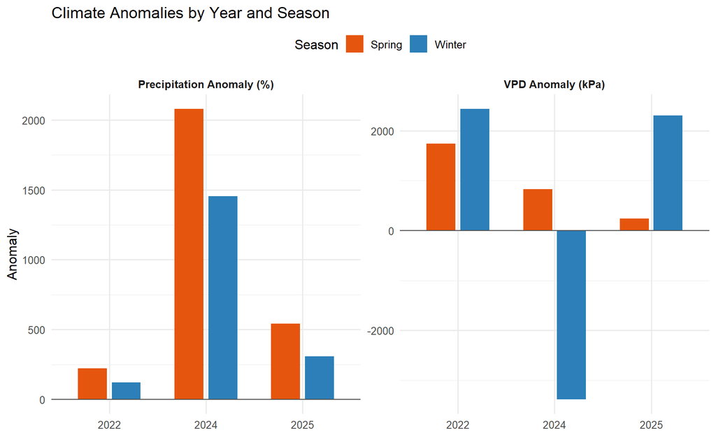

## RangeMap Fuel Model Annual Composition

RangeMap FBFM40 percent composition by year

| Year | NB9 | GR1 | GR2 | GS1 | GS2 | SH1 | SH2 | SH7 |
| --- | --- | --- | --- | --- | --- | --- | --- | --- |
| 2022 | 19.50 | 15.31 | 0.01 | 51.77 | 0.02 | 11.97 | 1.32 | 0.09 |
| 2024 | 3.22 | 12.51 | 0.02 | 79.14 | 0.03 | 2.41 | 2.59 | 0.08 |
| 2025 | 13.79 | 18.65 | 0.01 | 56.95 | 0.01 | 10.11 | 0.38 | 0.10 |

> As expected, 2024 (the wettest year) had the lowest proportion of nonburnable (NB9) areas. NB9 composition was 10% higher in 2025 (which was a fairly wet year) than 2024, and another 6% higher in 2022 (which was a fairly typical year). Interestingly, 2024 is showing a large increase not in GR fuel models, but in GS fuel models. Some of this is explained by SH1 fuel models in 2022 and 2025 changing to GS1 fuel models in 2024, which makes sense given higher grass loads in a wet year. However, this also means the NB9 fuel model areas in 2022 and 2025 are mainly changing to GS1 rather than GR1, which might be more suspect.

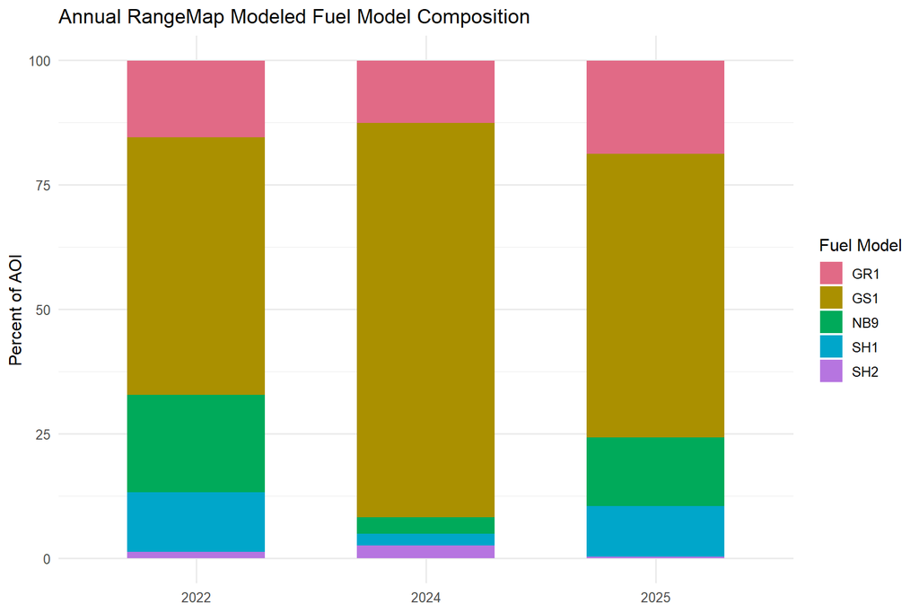

## LANDFIRE Fuel Model Annual Composition

LANDFIRE FBFM40 percent composition by year

| Year | NB9 | GR1 | GR2 | GS1 | GS2 | SH1 | SH2 |
| --- | --- | --- | --- | --- | --- | --- | --- |
| 2022 | 60.05 | 0.30 | 10.50 | 11.03 | 3.44 | 14.52 | NA |
| 2024 | 60.04 | 0.32 | 10.52 | 1.01 | 4.43 | 14.48 | 9.07 |
| 2025 | 60.04 | 0.38 | 10.53 | 1.01 | 4.43 | 14.46 | 9.02 |

> LANDFIRE is not responsive to annual climatic or spectral changes. LANDFIRE only varies year to year in places that are newly disturbed, or had been recently disturbed. Between 2022, 2024 and 2025, there is no change in nonburnable fuel model composition. There is almost no change in other fuel models, besides GS1 pixels in 2022 changing to GS2 and SH2 in 2024 and 2025 (likely because these pixels had previously been disturbed, and were moved to a new fuel model following recovery).

## Summary

- **Fuel models assigned by RangeMap followed annual climate anomalies**
  - Nonburnable area decreased in wetter years, with nonburnable and SH1 pixels changing to GS1 in wetter years.
- **LANDFIRE does not reflect annual climate anomalies**
  - Fuel models from LANDFIRE did not change annually from climate anomalies or spectral changes. However, LANDFIRE fuel models do change somewhat between vintages due to disturbance and post-disturbance dynamics, and these changes could be conflated with changes responsive to annual climate anomalies. Here, LANDFIRE shows pixels moving from GS1 to SH2 due to post-disturbance dynamics, and this change happens to line up with wetter years.
- **RangeMap and LANDFIRE show different fuel model compositions generally**
  - LANDFIRE shows a much higher composition of nonburnable area than RangeMap (60% of the area in LANDFIRE, versus 3-20% in RangeMap). This has big implications on potential for fire spread in these areas. All 3 years analyzed here were wetter than normal, so RangeMap will likely show a greater composition of nonburnable area in other years that were drier than normal, but this may not approach the 60% composition shown by LANDFIRE.
  - LANDFIRE shows almost no GR1 or GS1 pixels in the area, whereas these are the main fuel models in RangeMap. Instead, LANDFIRE jumps straight from nonburnable to GR2, GS2, and SH1 and SH2 in many cases. This seems strange because this is a desert area, and there should likely be more areas reflecting the low fuel GR1 and GS1 fuel models (with about 800 to 2700 lbs/acre of fuel), whereas LANDFIRE is going straight to the GR2 and GS2 fuel models in more cases (2200 to 4200 lbs/acre).